# crashes with respect to hours and URI

(View HTML version of this file by placing the URL in http://htmlpreview.github.io/) The data set is extracted using the following python query

```python
u1 = u0.filter("app_name='Firefox' and normalized_channel='release'
                 and os='Windows_NT' and sample_id in ({})".format( ",".join(samplechar)))
ms4 = sqlContext.sql("""
select
client_id,
app_version                     as version,
os_version                      as osversion,
submission_date                 as date,
sum(crashes_detected_content)   as contentcrashes,
sum(crashes_detected_gmplugin)  as mediacrashes,
sum(crashes_detected_plugin)    as plugincrashes,
sum(crash_submit_success_main)  as browsercrash,
sum(subsession_length)/3600     as hrs,
sum(total_uri_count)            as uri,
sum(unique_domains_count)       as domain
from ms3
where submission_date>='20161201' and os_version in ('6.1', '6.2', '6.3', '10.0')
group by 1,2,3,4
""")

write = pyspark.sql.DataFrameWriter(ms4.coalesce(100))
write.csv(path="s3://mozilla-metrics/sguha/uricrashes/",mode='overwrite',nullValue="NA",header=True)
```

## Is m1=crashes/total hours substantially different from m2=crashes/URI

The question is better phrased as: do the two measures behave in a similar manner i.e.

- do they have the same day of week effect?
- do they have the same trend?
- do they have the same larger seasonal cycles?
- are they correlated across time?

If the above questions are answered positively, we can use one in place of the of the other. Rather since crashes/total hours is what is being used now, it might not be needed to substitute it with crashes/URI.

## By clients

I studied the relationship of m1 and m2 per client and aggregated it above (across their time period of activity in the dataset which is typically 16 days). For those profiles with at least 3 days of activity the kendall correlation coefficient for m1 and m2 is greater than 0.9. Since crashes are rare events(and so crash rate is mostly 0), this is not really informative.

```r
p6 <- t(map = function(a, b) {
    if (nrow(b) > 5) {
        x <- runif(1)
        co <- b[hrs > 0 & uri > 0, ][, list(cid = rep(x, .N), c = contentcr +
            allplugincr, u = uri, h = hrs)]
        rhcollect(sample(1:100, 1), co)
    }
}, reduce = dtbinder)
p6d <- rbindlist(lapply(p6$collect(), "[[", 2))
p6d5 <- p6d[, .SD[c > 0, ], by = cid][, if (.N > 2) list(cr = cor(c/(h + 1),
    c/(u + 1), use = "pairwise.complete.obs", method = "kendall")), by = cid]
```

For profiles that have more than 3 days with crashes, the correlation for m1 and m2 computed for those days with crashes the median correlation is 0.410 (mean is 0.41) and 30% have correlations larger than 0.66.

## The relationship between the time series graphs of m1 and m2

What most people will think of is how do the time series i.e. (date,m1) and (date,m2) relate to each other. The following is a figure with both graphs normalized to [0,1] (m1n and m2n). Also the figures have been scaled (by their mean and standard deviation) (m1s and m2s).

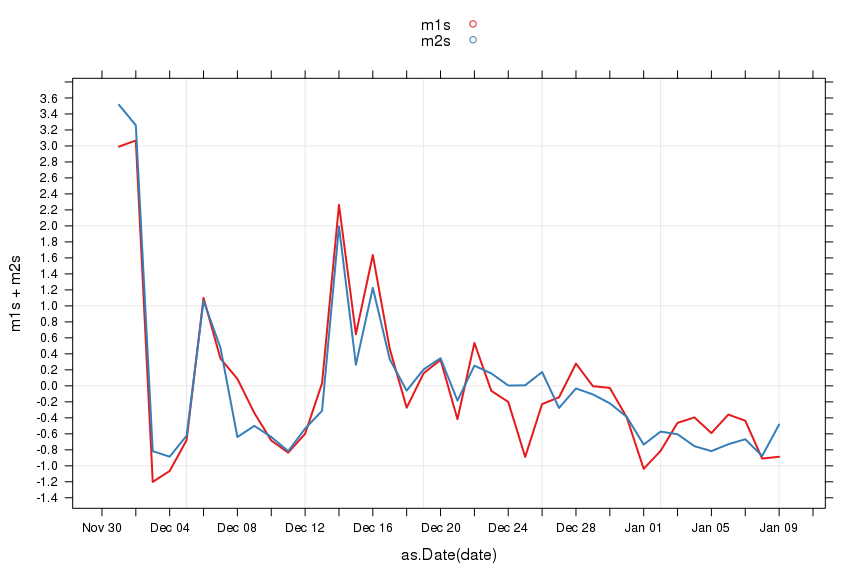

```r
xyplot( m1s + m2s ~ as.Date(date), auto.key=TRUE, lwd=2,type=c("l",'g'),scale=list(tick.num=20),data=p9d)
```

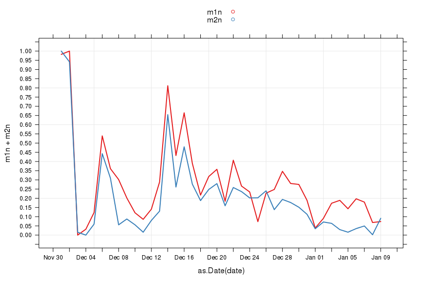

```r
xyplot( m1n + m2n ~ as.Date(date), auto.key=TRUE, lwd=2,type=c("l",'g'),scale=list(tick.num=20),data=p9d)
```

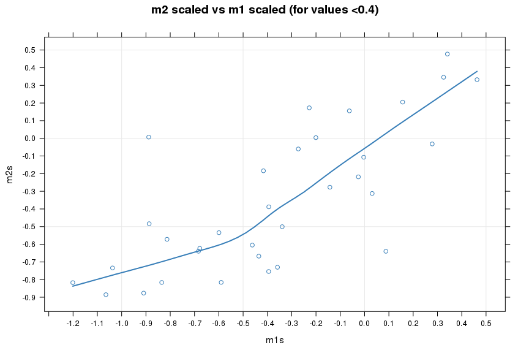

```r
xyplot( m2s ~ m1s , auto.key=TRUE, lwd=2,type=c("p",'g','smooth'),scale=list(tick.num=20),data=p9d[order(m1s),][m1n<0.4,],main="m2 scaled vs m1 scaled (for values <0.4)")
```

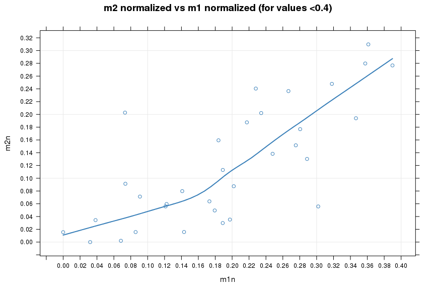

```r
xyplot( m2n ~ m1n , auto.key=TRUE, lwd=2,type=c("p",'g','smooth'),scale=list(tick.num=20),data=p9d[order(m1n),][m1n<0.4,],main="m2 normalized vs m1 normalized (for values <0.4)")
```